# Lab 5 Possion

STA 602: Bayesian and Modern Statistics

FEB 22, 2024

# Housekeeping

## R/RStudio

You all should have R and RStudio installed on your computers by now. If you do not, first install the latest version of R here: https://cran.rstudio.com (remember to select the right installer for your operating system). Next, install the latest version of RStudio here: https://www.rstudio.com/products/rstudio/download/. Scroll down to the “Installers for Supported Platforms” section and find the right installer for your operating system.

## R Markdown

You are required to use R Markdown to type up this lab report. If you do not already know how to use R markdown, refer to Sakai “Resources/Lab” folder for a very basic R Markdown template as well as a list of resources to help you learn how to use R markdown and LaTex.

## Gradescope

You MUST submit both your .Rmd and .pdf files to Gradescope. Make sure to knit to pdf and not html; ask the TA about knitting to pdf if you cannot figure it out. Be sure to submit under the right assignment entry.

# Getting started

This course will assume that you have some familiarity with the R programming language. However, to refresh your memory on some R key topics, this lab will go through some basic aspects of R functionality that will be important for future exercises.

# Data

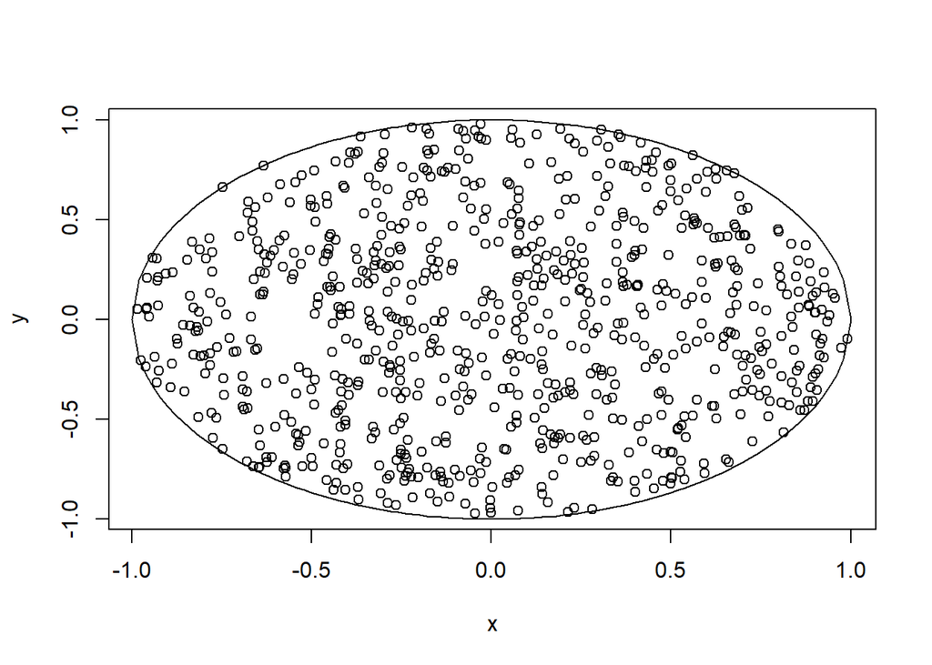

```r
x <- runif(1000,-1,1)
y <- runif(1000,-1,1)
idx <- (x^2 + y^2 < 1)

plot(x[idx], y[idx], xlab="x", ylab="y")
curve((  1 * (1 - x^2)^0.5 ), add=TRUE, from=-1 , to =1)
curve(( -1 * (1 - x^2)^0.5 ), add=TRUE, from=-1 , to =1)
```

# Exercise 1 Answer the questions - No, because the exponential distribution takes 0 on the negative x-interval, and the proposed M will not be finite.

- On the other hand, we can use normal distribution as the candidate to sample from Cauchy.
- For univarite core, it could work.For multidim cases, (say 100 variables, ), The volume of the region of interest becomes exponentially smaller as the number of dimensions increases, leading to a lower probability of accepting a sample. This phenomenon is often referred to as the “curse of dimensionality.”

# Exercise 2 Answer the questions

M’=1 (with max at $\theta=0.5$). If for the corresponding pdf $f(\theta)$, the M should be larger.

# Exercise 3 Answer the questions

```r
library(ggplot2)

# Define the target density function
f <- function(x) {
  sin(pi * x)^2
}

# Number of samples desired
nsim <- 10000

# Initialize variables for acceptance count
ac <- tc <- 0
res <- numeric(nsim)

# Rejection Sampling process, to generate nsim
while (ac < nsim) {
  tc <- tc + 1
  x_proposed <- runif(1, 0, 1)
  u <- runif(1, 0, 1)

  if (u <= f(x_proposed)) {
    ac <- ac + 1
    res[ac] <- x_proposed
  }
}

#Accept Rate
print(ac/tc)
```

```
## [1] 0.51
```

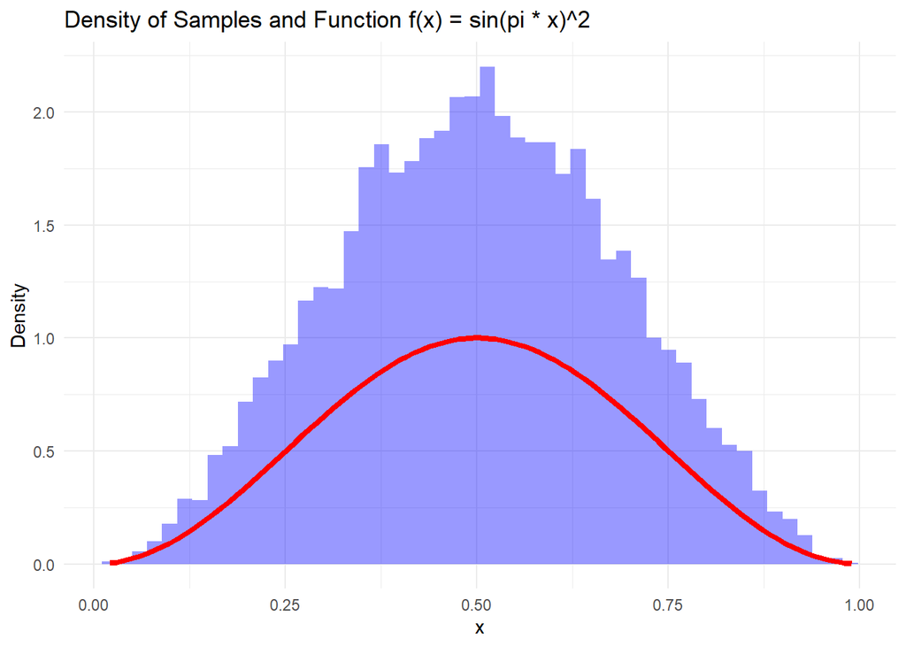

```r
# Plotting the density of the samples
ggplot(data.frame(x = res), aes(x)) +
  geom_histogram(aes(y = ..density..), bins = 50, fill = "blue", alpha = 0.4) +
  stat_function(fun = f, color = "red", size = 1.5) +
  labs(title = "Density of Samples and Function f(x) = sin(pi * x)^2",
       x = "x",
       y = "Density") +
  theme_minimal()
```

# Exercise 4 - The size is very different from the plot of $sin^2(\pi x)$ since the latter one is not a proper density. - The accepted rate is around 0.5 and will decrase when M becomes larger. The relative shape not change

```r
library(ggplot2)

# Define the target density function
f <- function(x) {
  sin(pi * x)^2
}

# Number of samples desired
nsim <- 10000

# Initialize variables for acceptance count
ac <- tc <- 0
res <- numeric(nsim)
while (ac < nsim) {
  tc <- tc + 1
  x_proposed <- runif(1, 0, 1)
  u <- runif(1, 0, 1)

  if (u <= f(x_proposed)/5) {#Try different M
    ac <- ac + 1
    res[ac] <- x_proposed
  }
}

#Accept Rate
print(ac/tc)
```

```
## [1] 0.099
```

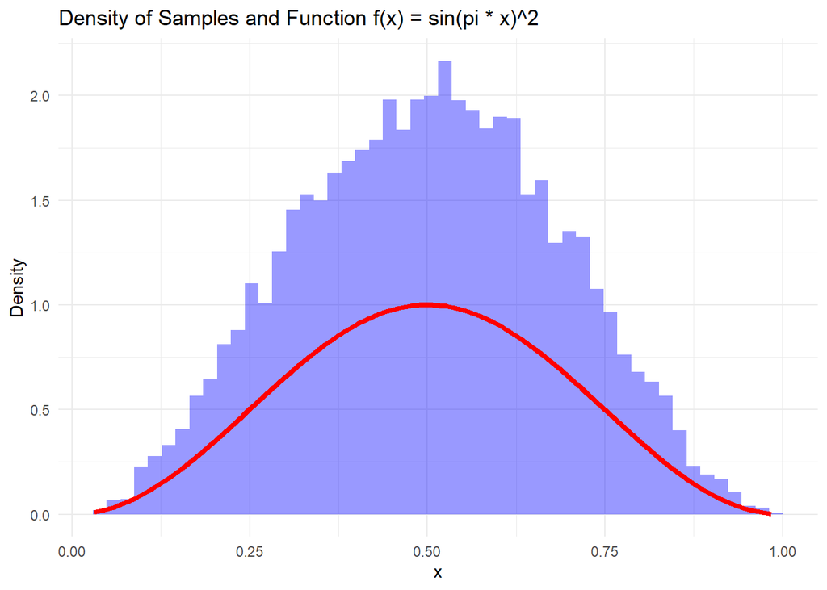

```r
# Plotting the density of the samples
ggplot(data.frame(x = res), aes(x)) +
  geom_histogram(aes(y = ..density..), bins = 50, fill = "blue", alpha = 0.4) +
  stat_function(fun = f, color = "red", size = 1.5) +
  labs(title = "Density of Samples and Function f(x) = sin(pi * x)^2",
       x = "x",
       y = "Density") +
  theme_minimal()
```

# Exercise 5: trying a different g: Beta(2,2)

```r
library(ggplot2)


# Define the target density function
f <- function(x) {
  sin(pi * x)^2
}

# Number of samples desired
nsim <- 10000

# Find M
ss=seq(0.001,0.999,0.001)
M<-max(f(ss)/dbeta(ss,2,2))


# Initialize variables for acceptance count
ac <- tc <- 0
res <- numeric(nsim)
while (ac < nsim) {
  tc <- tc + 1
  x_proposed <- rbeta(1,2,2)
  u <- runif(1, 0, 1)

  if (u <= f(x_proposed)/(M*dbeta(x_proposed,2,2))) {#Try different M
    ac <- ac + 1
    res[ac] <- x_proposed
  }
}

#Accept Rate
print(ac/tc)
```

```
## [1] 0.75
```

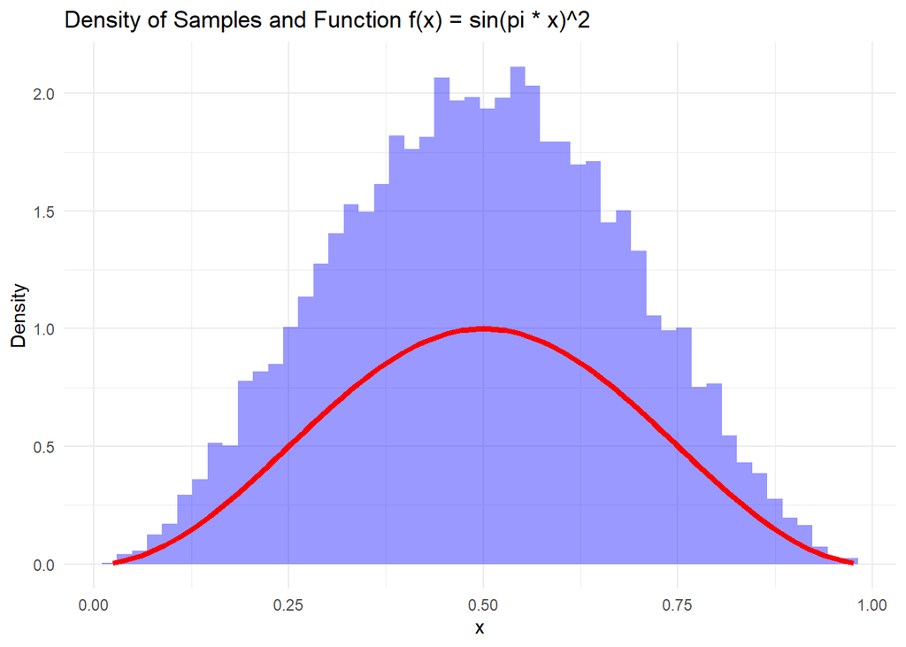

```r
# Plotting the density of the samples
ggplot(data.frame(x = res), aes(x)) +
  geom_histogram(aes(y = ..density..), bins = 50, fill = "blue", alpha = 0.4) +
  stat_function(fun = f, color = "red", size = 1.5) +
  labs(title = "Density of Samples and Function f(x) = sin(pi * x)^2",
       x = "x",
       y = "Density") +
  theme_minimal()
```

# Exercise 6: Self-normalizing IS:

The estimator is calculated by

$$\frac{E_q[h(x)w(x)]}{E_q[w(x)]},where \quad w=\frac{f^*}{g^*}$$

# Exercise 7: IS application

leveraging on the concept of IS can save us the efforts of re-sampling in sensitive analysis.For expectation on h(X):

$$E_q[h(x)w(x)],where \quad w=\frac{p(
\theta|y,\psi_1
)}{p(
\theta|y,\psi_0)}$$

# Exercise 8: IS application continue

$$\frac{E_q[h(x)w(x)]}{E_q[w(x)]},where \quad w=\frac{p^*(
\theta|y,\psi_1
)}{p^*(
\theta|y,\psi_0)}$$

```r
tumors <- read.csv(file = url("http://www.stat.columbia.edu/~gelman/book/data/rats.asc"),
                     skip = 2, header = T, sep = " ")[,c(1,2)]
y <- tumors$y
N <- tumors$N
n <- length(y)

stan_dat <- list(n = n, N = N, y =y, a = 1, b = 1)
fit_pool <- stan('lab-02-pool.stan', data = stan_dat, chains = 2, refresh = 0)
pool_output <- rstan::extract(fit_pool)
```

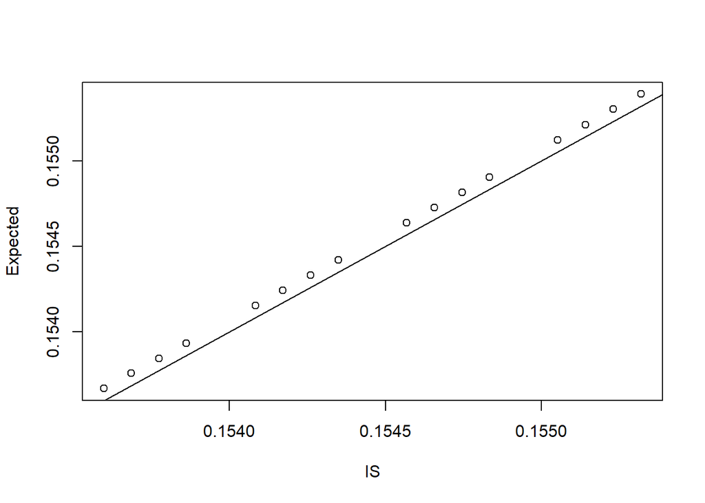

```r
as <- c(1,10,25,100)
bs <- c(1,10,25,100)

# posterior parameters under the current Beta(1,1) prior
post_a0 <- 1 + sum(y)
post_b0 <- 1 + sum(N) - sum(y)

#sampling theta from q
theta_q=pool_output$theta

IS_sensi_mean <- matrix(0, length(as), length(bs))  # IS estimated posterior mean
exp_sensi_mean <- matrix(0, length(as), length(bs))  # theoretical posterior mean

for (i in (1:length(as))){
  for (j in (1:length(bs))){
    post_a1 <- i + sum(y)
    post_b1 <- j + sum(N) - sum(y)
    exp_sensi_mean[i,j]<-post_a1/(post_a1+post_b1)
    w=dbeta(theta_q,post_a1,post_b1)/dbeta(theta_q,post_a0,post_b0)
    IS_sensi_mean[i,j]<-sum(theta_q*w)/sum(w) #self-normalizing

    # fill in your codes here

  }
}

# plot the theoretical posterior means against the IS estimated posterior means
plot(c(IS_sensi_mean), c(exp_sensi_mean), xlab = "IS", ylab = "Expected")
abline(a = 0, b = 1)  # 45 degree line
```

- Notice the self normalizing works well.
- For non-selfnormalizing, larger difference in a and b will make larger difference, so IS is not efficient.

# R tutorials and resources

For more information on the R programming language please refer to some or all of the following resources:

- [R for Data Science](https://r4ds.had.co.nz/)
- [ggplot2](https://ggplot2.tidyverse.org/)
- [ColorBrewer](http://colorbrewer2.org/)

# Acknowledgement

This lab was created by [Jordan Bryan](https://scholars.duke.edu/person/jordan.bryan) and [Becky Tang](https://scholars.duke.edu/person/becky.tang).